# Elastic-Net binomial para textos

Tarssio Barreto

2019-05-21

## Pacotes que serão utilizados:

```r
#install.packages("pacman")
library(pacman)


p_load(caret, tidyverse, factoextra, epubr, tm, lexiconPT, broom, tidytext, widyr, irlba, rsample, glmnet)
```

## Ajustes

Começamos, assim como as demais publicações, carregando os ebooks dos livros: “O Estrangeiro” e “Crime e Castigo”. Estamos trabalhando com eles há três publicações, qualquer coisa, olhem as antigas.

```r
x0 <- epubr::epub("C:/Users/tarss/Desktop/SER/CURO_SER/O Estrangeiro - Albert Camus.epub")

x1 <- epubr::epub("C:/Users/tarss/Desktop/SER/CURO_SER/Crime e Castigo - Fiódor Dostoiévski.epub")
```

## Tratando os textos:

Para os textos em questão vamos contar o numéro de vezes que cada palavra se repete por paragráfo já que nosso objetivo final é criar um modelo quais palavras são fortemente associadas aos parágrafos de cada um dos livros.

### O estrangeiro

Vamos utilizar as funções do tidytext para ajustar os bancos de dados para aquilo que queremos. Removeremos também as stopwords.

```r
# Removendo Stopwords
stop_words <- stopwords(kind = "pt") %>%
  as.tibble()

stop_words <- rbind(stop_words, c("é"))

colnames(stop_words)[1] <- "word"

# ajustando estrangeiro

estrangeiro <- x0$data[[1]]


estrangeiro_ <- estrangeiro %>%
  tidytext::unnest_tokens(paragraphs, text, token = "paragraphs") %>%
  mutate(paragrafo = row_number()) %>%
  tidytext::unnest_tokens(word, paragraphs) %>%
  anti_join(stop_words, by = "word")  %>%
  count(paragrafo, word, sort = TRUE) %>%
  mutate(book = "estrangeiro")

head(estrangeiro_)
```

```
## # A tibble: 6 x 4
##   paragrafo word         n book
##       <int> <chr>    <int> <chr>
## 1       146 cão          8 estrangeiro
## 2       417 maria        6 estrangeiro
## 3       265 raimundo     5 estrangeiro
## 4       334 juiz         5 estrangeiro
## 5       362 cada         5 estrangeiro
## 6       424 raimundo     5 estrangeiro
```

```r
id <- max(estrangeiro_$paragrafo)
```

### Crime e Castigo

```r
crime <- x1$data[[1]]

crime_ <- crime %>%
  tidytext::unnest_tokens(paragraphs, text, token = "paragraphs") %>%
  mutate(paragrafo = row_number() + id) %>%  # somamos ao id para termos continuidade no id dos paragrafos
  tidytext::unnest_tokens(word, paragraphs) %>%
  anti_join(stop_words, by = "word")  %>%
  count(paragrafo, word, sort = TRUE) %>%
  mutate(book = "crime")

head(crime_)
```

```
## # A tibble: 6 x 4
##   paragrafo word          n book
##       <int> <chr>     <int> <chr>
## 1      3352 ivánovna     40 crime
## 2      3332 ivánovna     33 crime
## 3      3782 senhor       32 crime
## 4       693 dúnia        29 crime
## 5      3352 catierina    24 crime
## 6       693 tudo         21 crime
```

## Nosso banco de dados final fica:

```r
df <- rbind(estrangeiro_, crime_)

head(df)
```

```
## # A tibble: 6 x 4
##   paragrafo word         n book
##       <int> <chr>    <int> <chr>
## 1       146 cão          8 estrangeiro
## 2       417 maria        6 estrangeiro
## 3       265 raimundo     5 estrangeiro
## 4       334 juiz         5 estrangeiro
## 5       362 cada         5 estrangeiro
## 6       424 raimundo     5 estrangeiro
```

```r
range(df$paragrafo)
```

```
## [1]    1 4356
```

```r
## Removendo nomes e outras stopwords que dificultam o entendimento da questão


nomes <- c("raskólnikov", "sônia", "razumíkhin", "ivánova", "pietróvitch", "n",
           "catierina", "dúnia", "svidrigáilov", "porfiri", "piotr", "pulkhéria",
           "t", "avdótia", "ródia", "románovna", "rodíon", "lújin", "atieksándrovna",
           "dúnietchka", "zóssimov", "zamiótov", "marfa", "sófia", "semeónovna",                "nastácia",
           "pietróvna", "raskólnikovnn", "amália", "liebeziátnikov", "raimundo",                 "masson", "u",
           "perez", "manuel", "meursault", "ivánovna", "alieksándrovna", "lisavieta",             "ei", "capítulo",
           "19", "si", "alguma", "agora", "jeito", "instalamo", "ora", "algum", "há",            "ainda", "descemos",
           "respondi","instante", "bocadinho", "soubera", "ah", "vou")


aux <- df %>%
  filter(!word %in% nomes)
```

## Treino e Teste

Agora utilizaremos o pacote `rsample` para dividir nosso banco de dados final em treino e teste para que possamos realizar a modelagem e testar a sua capacidade de generalização.

```r
books_split <- aux %>%
  select(paragrafo, book) %>%
  initial_split()

train_data <- training(books_split)
test_data <- testing(books_split)
```

## Matriz Esparsa

Como todas as postagens anteriores, criaremos, também, nossa matriz esparsa na qual as linhas são representadas pelos paragráfos, as colunas pelas palavras e são preenchidas pelo número de vezes que cada palavra aparece em cada um dos paragráfos.

```r
sparse_words <- aux %>%
  inner_join(train_data) %>%
  cast_sparse(paragrafo, word, n)

word_rownames <- as.integer(rownames(sparse_words))
```

## Modelando os dados de treino

Carregando os dados de treino:

```r
model_df <- train_data %>%
  filter(paragrafo %in% word_rownames) %>%
  distinct()
```

##Criando uma variável que tem valores 0 e 1 para ser ou não o livro estrangeiro:

Neste caso, estamos criando nosso Y (variável binária que queremos modelar)

```r
is_camus <- model_df$book == "estrangeiro"
```

## Elastic-net Binomial

Vamos criar um modelo elastic-net cuja familia é binominal, desta forma realizamos algo muito parecido com a regressão logistica, mas com as vantagens de seleção de variáveis dada pelo elastic-net.

O Elastic Net é um modelo regularizado na qual há um sistema de penalidades que busca zerar os valores dos coeficientes de algumas variáveis que possuem pouca influência no modelo final.

```r
model <- glmnet::cv.glmnet(sparse_words, is_camus,
                   family = "binomial",
                   keep = TRUE)

model
```

[output not shown]

[output cut: 19399 more lines]

Observamos, então, as palavras que mais contribuem para que dado paragráfo seja, ou não, do livro: O Estrangeiro.

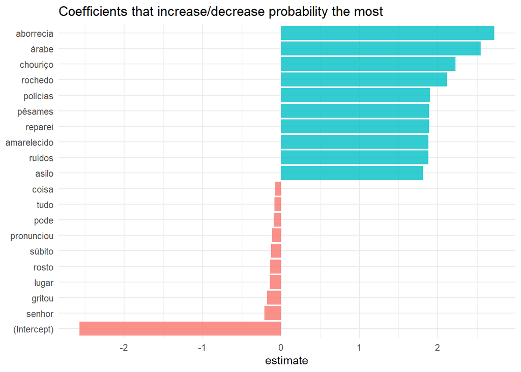

```r
coefs <- model$glmnet.fit %>%
  tidy() %>%
  filter(lambda == model$lambda.1se)


coefs %>%
  group_by(estimate > 0) %>%
  top_n(10, abs(estimate)) %>%
  ungroup() %>%
  ggplot(aes(fct_reorder(term, estimate), estimate, fill = estimate > 0)) +
  geom_col(alpha = 0.8, show.legend = FALSE) +
  coord_flip() +
  labs(
    x = NULL,
    title = "Coefficients that increase/decrease probability the most"
  ) +
  theme_minimal()
```

## Testando e Validando

Para validar um modelo, devemos ver o quão bem este é capaz de generalizar a predição para os valores de teste. Pegaremos nosso conjunto de teste, retornaremos o intercepto e os valores estimados e aplicaremos isto nos dados de teste para retornar a probabilidade de determinado paragráfo pertencer ao livro do Albert Camus.

```r
# Encontrando o intercepto


intercept <- coefs %>%
  filter(term == "(Intercept)") %>%
  pull(estimate)

# Realizando a classificação, ou seja, qual a probabilidade de tal paragráfo, do grupo de teste, ser do livro "O Estrangeiro"

classifications <- aux %>%
  inner_join(test_data) %>%
  inner_join(coefs, by = c("word" = "term")) %>%
  group_by(paragrafo) %>%
  summarize(score = sum(estimate)) %>%
  mutate(probability = plogis(intercept + score))  # Retornar a probabilidade

head(classifications)
```

```
## # A tibble: 6 x 3
##   paragrafo score probability
##       <int> <dbl>       <dbl>
## 1         3  3.62       0.741
## 2         6 12.3        1.000
## 3         7 10.2        1.000
## 4         9 14.4        1.000
## 5        10 12.0        1.000
## 6        11  3.21       0.654
```

## Juntando os bancos de dados de classificação e teste:

Vamos separar as classificações dadas as observações de teste e escolheremos 0.5 como threshold da classicação. Este passo será fundamental para posterior criação da matriz de confusão.

```r
# Testando os resultados

test_df <- test_data %>%
  filter(paragrafo %in% classifications$paragrafo) %>%
  distinct()


test <- inner_join(classifications,test_df) %>%
  mutate(book = as.factor(book))

### Escolhendo 0.5 como threshold para classificação:

test <- test %>%
  mutate(
    prediction = case_when(
      probability > 0.5 ~ "estrangeiro",
      TRUE ~ "crime"
    ),
    prediction = as.factor(prediction))
```

## Resultado Final

Temos um modelo de alta acurácia, boa sensitividade e sensibilidade, mesmo não sendo balanceado. Claro, que são dois livros distintos, em contextos distintos, mas é uma aplicação bastante interessante e que abre possibilidade para outras.

```r
caret::confusionMatrix(test$prediction, test$book)
```

```
## Confusion Matrix and Statistics
##
##              Reference
## Prediction    crime estrangeiro
##   crime        1758          42
##   estrangeiro   274         410
##
##                Accuracy : 0.8728
##                  95% CI : (0.859, 0.8856)
##     No Information Rate : 0.818
##     P-Value [Acc > NIR] : 9.16e-14
##
##                   Kappa : 0.6438
##
##  Mcnemar's Test P-Value : < 2.2e-16
##
##             Sensitivity : 0.8652
##             Specificity : 0.9071
##          Pos Pred Value : 0.9767
##          Neg Pred Value : 0.5994
##              Prevalence : 0.8180
##          Detection Rate : 0.7077
##    Detection Prevalence : 0.7246
##       Balanced Accuracy : 0.8861
##
##        'Positive' Class : crime
##
```